# STAT 545A Homework 5

Junbin ZHANG

Oct 09, 2018

# Bring rectangular data in

```r
## load gapminder
suppressPackageStartupMessages(library(gapminder))
## load tidyverse
suppressPackageStartupMessages(library(tidyverse))
## load forcats
suppressPackageStartupMessages(library(forcats))
```

# Part 1: Factor management

## Drop Oceania

Before dropping Oceania, let’s check the number of rows in `gapminder`, and the levels of `continent`.

```r
gapminder %>%
  # get the number of rows and levels of continent
  summarize(
    nrow = nrow(gapminder),
    nlevels = nlevels(gapminder$continent)
  ) %>%
  # show the table
  knitr::kable(col.names = c("Number of rows", "Levels of `continent`"))
```

| Number of rows | Levels of `continent` |
| --- | --- |
| 1704 | 5 |

Let’s first try to drop Oceania, and show the number of rows, and the levels of `continent`.

```r
# drop Oceania
drop <- gapminder %>%
  filter(continent != "Oceania")

drop %>%
  # get the number of rows and levels of continent
  summarize(
    nrow = nrow(drop),
    nlevels = nlevels(drop$continent)
  ) %>%
  # show the table
  knitr::kable(col.names = c("Number of rows after dropping", "Levels of `continent` after dropping"))
```

| Number of rows after dropping | Levels of `continent` after dropping |
| --- | --- |
| 1680 | 5 |

Here we can see, even we remove all rows associated with the `continent` of Oceania (so the number of rows decrease), the levels of `continent` is unchanged. However, it is a wrong value. To fix it, we need to `droplevels()` to solve the issue.

```r
# drop levels
drop_levels <- drop %>%
  droplevels()

drop_levels %>%
  # get the number of rows and levels of continent
  summarize(
    nrow = nrow(drop_levels),
    nlevels = nlevels(drop_levels$continent)
  ) %>%
  # show the table
  knitr::kable(col.names = c("Number of rows after dropping levels", "Levels of `continent` after dropping levels"))
```

| Number of rows after dropping levels | Levels of `continent` after dropping levels |
| --- | --- |
| 1680 | 4 |

To summarize, we address the number of rows and the levels of `continent` before and after removing Oceania.

```r
# build a tibble with statistics
summary <- cbind(
  before = c(
    nrow(gapminder),
    nlevels(gapminder$continent)
  ),
  after = c(
    nrow(drop_levels),
    nlevels(drop_levels$continent)
  )
)

# assign row names
rownames(summary) <- c("Number of rows", "Levels")

# display the table
summary %>%
  knitr::kable()
```

|  | before | after |
| --- | --- | --- |
| Number of rows | 1704 | 1680 |
| Levels | 5 | 4 |

## Reorder the levels of `country` and `continent`

Let’s show a preview of our dropped version of `gapminder` before reordering.

```r
# show previews
head(drop_levels) %>%
  knitr::kable()
```

| country | continent | year | lifeExp | pop | gdpPercap |
| --- | --- | --- | --- | --- | --- |
| Afghanistan | Asia | 1952 | 28.801 | 8425333 | 779.4453 |
| Afghanistan | Asia | 1957 | 30.332 | 9240934 | 820.8530 |
| Afghanistan | Asia | 1962 | 31.997 | 10267083 | 853.1007 |
| Afghanistan | Asia | 1967 | 34.020 | 11537966 | 836.1971 |
| Afghanistan | Asia | 1972 | 36.088 | 13079460 | 739.9811 |
| Afghanistan | Asia | 1977 | 38.438 | 14880372 | 786.1134 |

```r
tail(drop_levels) %>%
  knitr::kable()
```

| country | continent | year | lifeExp | pop | gdpPercap |
| --- | --- | --- | --- | --- | --- |
| Zimbabwe | Africa | 1982 | 60.363 | 7636524 | 788.8550 |
| Zimbabwe | Africa | 1987 | 62.351 | 9216418 | 706.1573 |
| Zimbabwe | Africa | 1992 | 60.377 | 10704340 | 693.4208 |
| Zimbabwe | Africa | 1997 | 46.809 | 11404948 | 792.4500 |
| Zimbabwe | Africa | 2002 | 39.989 | 11926563 | 672.0386 |
| Zimbabwe | Africa | 2007 | 43.487 | 12311143 | 469.7093 |

From a bigger picture, this data frame is ordered by the alphabetical order of `country`. Let’s try to reorder the levels of `country` by the maximum population over the years using `fct_reorder()`. Note that it is reordered in ascending order, so the first level is the one with least maximum population over the year.

```r
fct_reorder(
  # reorder country
  drop_levels$country,
  # by pop
  drop_levels$pop,
  # using maximum
  max) %>%
  # show preview of resultant levels
  levels() %>%
  head() %>%
  knitr::kable(col.names = c("`country` after reordering"))
```

| `country` after reordering |
| --- |
| Sao Tome and Principe |
| Iceland |
| Djibouti |
| Equatorial Guinea |
| Bahrain |
| Comoros |

In order to check our results, we manually calculate the maximum population and order it.

```r
drop_levels %>%
  # group by country
  group_by(country) %>%
  # calcuate maximum population for each country
  summarize(
    max_pop = max(pop)
  ) %>%
  # arrange by max_pop
  arrange(max_pop) %>%
  # show preview
  head() %>%
  knitr::kable(col.names = c("country", "Maximum population over the years"))
```

| country | Maximum population over the years |
| --- | --- |
| Sao Tome and Principe | 199579 |
| Iceland | 301931 |
| Djibouti | 496374 |
| Equatorial Guinea | 551201 |
| Bahrain | 708573 |
| Comoros | 710960 |

So our operation using `fct_reorder` is correct.

We can do the same thing on `continent`. For example, we reorder its levels by the average life expectancy.

```r
fct_reorder(
  # reorder continent
  drop_levels$continent,
  # by lifeExp
  drop_levels$lifeExp,
  # using mean
  mean) %>%
  # show preview of resultant levels
  levels() %>%
  head() %>%
  knitr::kable(col.names = c("`continent` after reordering"))
```

| `continent` after reordering |
| --- |
| Africa |
| Asia |
| Americas |
| Europe |

We also double-check the results.

```r
drop_levels %>%
  # group by continent
  group_by(continent) %>%
  # calcuate mean lifeExp for each continent
  summarize(
    mean_lifeExp = mean(lifeExp)
  ) %>%
  # arrange by mean_lifeExp
  arrange(mean_lifeExp) %>%
  # show preview
  head() %>%
  knitr::kable(col.names = c("continent", "Average life expectancy over the years"))
```

| continent | Average life expectancy over the years |
| --- | --- |
| Africa | 48.86533 |
| Asia | 60.06490 |
| Americas | 64.65874 |
| Europe | 71.90369 |

## Characterize the (derived) data

In the previous section, we try to create two examples using `fct_reorder()` and `arrange()`, with identical results. Now, we try to reuse the first example and see if these two functions affect figures generated.

Let’s try the first example, using `fct_reorder()` only.

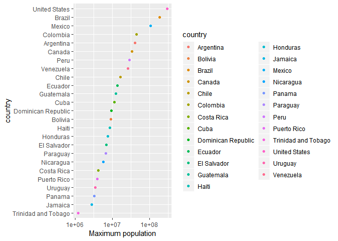

```r
drop_levels %>%
  # try to only show a continent
  filter(continent == "Americas") %>%
  # group by country
  group_by(country) %>%
  # calcuate maximum population for each country
  mutate(
    max_pop = max(pop)
  ) %>%
  # show preview of resultant levels
  ggplot(aes(x = max_pop, y = fct_reorder(country, pop, max), color = country)) +
  # make it a scatterplot
  geom_point() +
  # scale x axis by log10
  scale_x_log10() +
  # change axis labels
  xlab("Maximum population") +
  ylab("country")
```

Let’s do it with `arrange()` only.

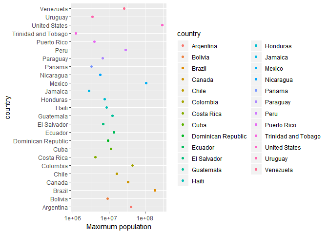

```r
drop_levels %>%
  # try to only show a continent
  filter(continent == "Americas") %>%
  # group by country
  group_by(country) %>%
  # calcuate maximum population for each country
  summarize(
    max_pop = max(pop)
  ) %>%
  # arrange by max_pop
  arrange(max_pop) %>%
  # show preview of resultant levels
  ggplot(aes(x = max_pop, y = country, color = country)) +
  # make it a scatterplot
  geom_point() +
  # scale x axis by log10
  scale_x_log10() +
  # change axis labels
  xlab("Maximum population") +
  ylab("country")
```

Now we use `fct_reorder()` with `arrange()`.

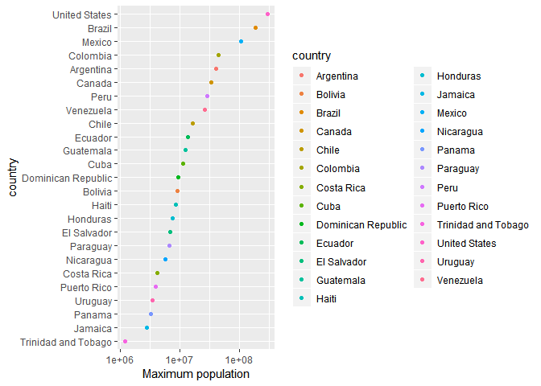

```r
drop_levels %>%
  # try to only show a continent
  filter(continent == "Americas") %>%
  # group by country
  group_by(country) %>%
  # calcuate maximum population for each country
  mutate(
    max_pop = max(pop)
  ) %>%
  # arrange by max_pop
  arrange(max_pop) %>%
  # show preview of resultant levels
  ggplot(aes(x = max_pop, y = fct_reorder(country, pop, max), color = country)) +
  # make it a scatterplot
  geom_point() +
  # scale x axis by log10
  scale_x_log10() +
  # change axis labels
  xlab("Maximum population") +
  ylab("country")
```

**Finding(s):** using `fct_reorder()` (no matter with `arrange()` or not) will change the order of levels shown in figures, while using `arrange()` along will not affect the order of levels.

# Part 2: File I/O

In order to test if mutated data can survire the round trip of writing and then reading back from a file, we first use the first example in Part 1 to mutate `gapminder`.

```r
data <- gapminder %>%
  # mutate country by maximum population
  mutate(
    country = fct_reorder(country, pop, max)
  ) %>%
  # group by country
  group_by(country) %>%
  # calculate maximum population
  summarize(
    max_pop = max(pop)
  )

# show summary of the data
data %>%
  glimpse()
```

```
## Observations: 142
## Variables: 2
## $ country <fct> Sao Tome and Principe, Iceland, Djibouti, Equatorial G...
## $ max_pop <dbl> 199579, 301931, 496374, 551201, 708573, 710960, 720230...
```

```r
# show previews
head(data) %>%
  knitr::kable()
```

| country | max_pop |
| --- | --- |
| Sao Tome and Principe | 199579 |
| Iceland | 301931 |
| Djibouti | 496374 |
| Equatorial Guinea | 551201 |
| Bahrain | 708573 |
| Comoros | 710960 |

```r
tail(data) %>%
  knitr::kable()
```

| country | max_pop |
| --- | --- |
| Pakistan | 169270617 |
| Brazil | 190010647 |
| Indonesia | 223547000 |
| United States | 301139947 |
| India | 1110396331 |
| China | 1318683096 |

## `write_csv()/read_csv()`

```r
# write to csv
write_csv(data, "data_csv.csv")
# read from csv
data_csv <- read_csv("data_csv.csv")
# show summary of the data
data_csv %>%
  glimpse()
```

```
## Observations: 142
## Variables: 2
## $ country <chr> "Sao Tome and Principe", "Iceland", "Djibouti", "Equat...
## $ max_pop <dbl> 199579, 301931, 496374, 551201, 708573, 710960, 720230...
```

```r
# show previews
head(data_csv) %>%
  knitr::kable()
```

| country | max_pop |
| --- | --- |
| Sao Tome and Principe | 199579 |
| Iceland | 301931 |
| Djibouti | 496374 |
| Equatorial Guinea | 551201 |
| Bahrain | 708573 |
| Comoros | 710960 |

```r
tail(data_csv) %>%
  knitr::kable()
```

| country | max_pop |
| --- | --- |
| Pakistan | 169270617 |
| Brazil | 190010647 |
| Indonesia | 223547000 |
| United States | 301139947 |
| India | 1110396331 |
| China | 1318683096 |

**Finding(s):** using CSV format, it requires R to parse each column with default formats. Therefore, the class of `country` changes from `<fct>` to `<chr>`. However, the data keeps unchanged.

## `saveRDS()/readRDS()`

```r
# save to rds
saveRDS(data, "data_rds.rds")
# read from rds
data_rds <- readRDS("data_rds.rds")

# show summary of the data
data_rds %>%
  glimpse()
```

```
## Observations: 142
## Variables: 2
## $ country <fct> Sao Tome and Principe, Iceland, Djibouti, Equatorial G...
## $ max_pop <dbl> 199579, 301931, 496374, 551201, 708573, 710960, 720230...
```

```r
# show previews
head(data_rds) %>%
  knitr::kable()
```

| country | max_pop |
| --- | --- |
| Sao Tome and Principe | 199579 |
| Iceland | 301931 |
| Djibouti | 496374 |
| Equatorial Guinea | 551201 |
| Bahrain | 708573 |
| Comoros | 710960 |

```r
tail(data_rds) %>%
  knitr::kable()
```

| country | max_pop |
| --- | --- |
| Pakistan | 169270617 |
| Brazil | 190010647 |
| Indonesia | 223547000 |
| United States | 301139947 |
| India | 1110396331 |
| China | 1318683096 |

**Finding(s):** `saveRDS()` and `readRDS()` can keep both data and classes of each column.

## `dput()/dget()`

```r
# put to file
dput(data, "data.txt")
# get from file
data_get <- dget("data.txt")

# show summary of the data
data_get %>%
  glimpse()
```

```
## Observations: 142
## Variables: 2
## $ country <fct> Sao Tome and Principe, Iceland, Djibouti, Equatorial G...
## $ max_pop <dbl> 199579, 301931, 496374, 551201, 708573, 710960, 720230...
```

```r
# show previews
head(data_get) %>%
  knitr::kable()
```

| country | max_pop |
| --- | --- |
| Sao Tome and Principe | 199579 |
| Iceland | 301931 |
| Djibouti | 496374 |
| Equatorial Guinea | 551201 |
| Bahrain | 708573 |
| Comoros | 710960 |

```r
tail(data_get) %>%
  knitr::kable()
```

| country | max_pop |
| --- | --- |
| Pakistan | 169270617 |
| Brazil | 190010647 |
| Indonesia | 223547000 |
| United States | 301139947 |
| India | 1110396331 |
| China | 1318683096 |

**Finding(s):** `dput()` and `dget()` can also keep both data and classes of each column.

# Part 3: Visualization design

# Part 4: Writing figures to file

# But I want to do more!

**Make a deeper exploration of the forcats packages.**

According to [this reference](http://r4ds.had.co.nz/factors.html), we try to explore the following functions of forcats packages:

- `fct_relevel()`;
- `fct_reorder2()`;
- `fct_infreq()` and `fct_rev()`;
- `fct_recode()`;
- `fct_collapse()`; and
- `fct_lump()`.

## `fct_relevel()`

We can use `fct_relevel()` to manually reorder levels. For example, we can move Canada to be the first data in this example (which in the figure is the bottom one).

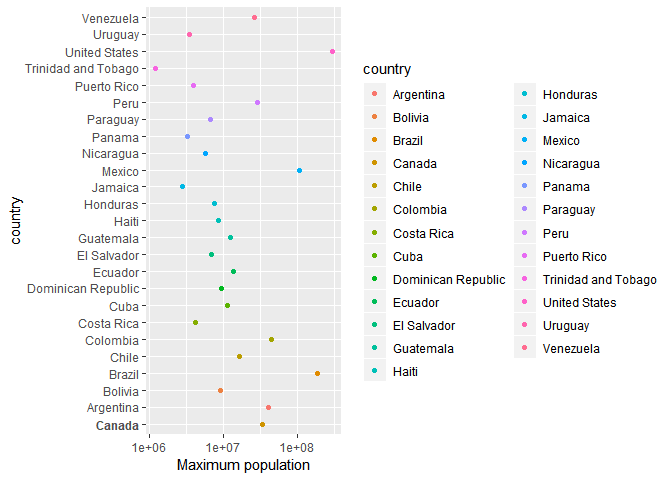

```r
drop_levels %>%
  # try to only show a continent
  filter(continent == "Americas") %>%
  # group by country
  group_by(country) %>%
  # calcuate maximum population for each country
  summarize(
    max_pop = max(pop)
  ) %>%
  # arrange by max_pop
  arrange(max_pop) %>%
  # show preview of resultant levels
  ggplot(aes(x = max_pop, y = fct_relevel(country, "Canada"), color = country)) +
  # make it a scatterplot
  geom_point() +
  # scale x axis by log10
  scale_x_log10() +
  # change axis labels
  xlab("Maximum population") +
  ylab("country") +
  # highlight Canada
  scale_y_discrete(labels = c("Canada" = expression(bold(Canada)), parse = TRUE))
```

## `fct_reorder2()`

We can use `fct_reorder2()` to reorder by two variables. For example, in the following example, we reorder by population first then GDP per capita (though it is not obvious).

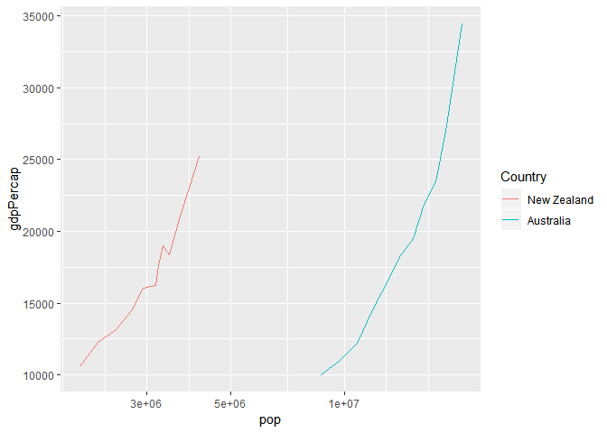

```r
gapminder %>%
  # show only Oceania
  filter(continent == "Oceania") %>%
  # pop as x axis and gdpPercap as y axis
  ggplot(aes(x = pop, y = gdpPercap, color = fct_reorder2(country, pop, gdpPercap, min))) +
  # make it a line plot
  geom_line() +
  # change label
  labs(color = "Country") +
  # scale x by log10
  scale_x_log10()
```

## `fct_infreq()` and `fct_rev()`

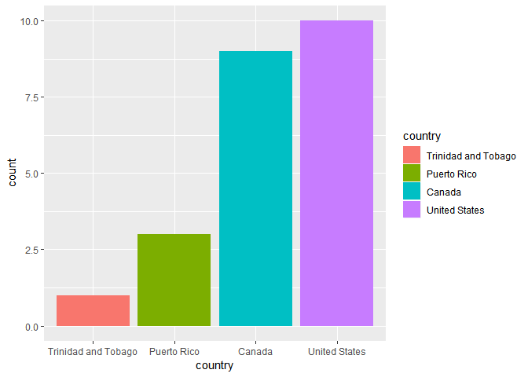

```r
gapminder %>%
  # show only a continent
  filter(continent == "Americas") %>%
  # filter countreis with gdpPercap larger than 15,000
  filter(gdpPercap >= 15000) %>%
  # reorder levels of country
  mutate(
    country = country %>% fct_infreq() %>% fct_rev()
  ) %>%
  # country as x axis
  ggplot(aes(x = country, fill = country)) +
  # make it as a bar plot
  geom_bar()
```

## `fct_recode()`

`fct_recode()` can be used to manully change the names of levels. For example, we try to change the name of “United States” in the above example.

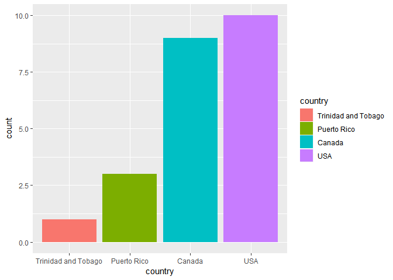

```r
gapminder %>%
  # show only a continent
  filter(continent == "Americas") %>%
  # filter countreis with gdpPercap larger than 15,000
  filter(gdpPercap >= 15000) %>%
  # reorder levels of country, and change name of "United States"
  mutate(
    country = country %>% fct_infreq() %>% fct_rev() %>%
      fct_recode(
        "USA" = "United States"
      )
  ) %>%
  # country as x axis
  ggplot(aes(x = country, fill = country)) +
  # make it as a bar plot
  geom_bar()
```

## `fct_collapse()`

We can try to use `fct_collapse()` to manually combine levels into groups. For example, we combined “Canada” and “USA” together in the above example.

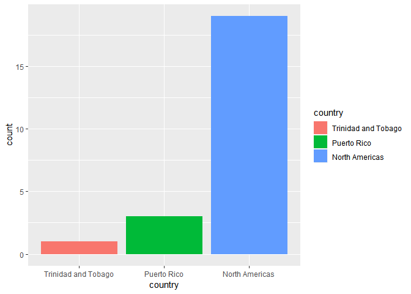

```r
gapminder %>%
  # show only a continent
  filter(continent == "Americas") %>%
  # filter countreis with gdpPercap larger than 15,000
  filter(gdpPercap >= 15000) %>%
  # reorder levels of country, and change name of "United States", and combine "Canada" and "USA"
  mutate(
    country = country %>% fct_infreq() %>% fct_rev() %>%
      fct_recode(
        "USA" = "United States"
      ) %>%
      fct_collapse(
        "North Americas" = c("Canada", "USA")
      )
  ) %>%
  # country as x axis
  ggplot(aes(x = country, fill = country)) +
  # make it as a bar plot
  geom_bar()
```

## `fct_lump()`

`fct_lump()` try to automaticaly aggregate groups.

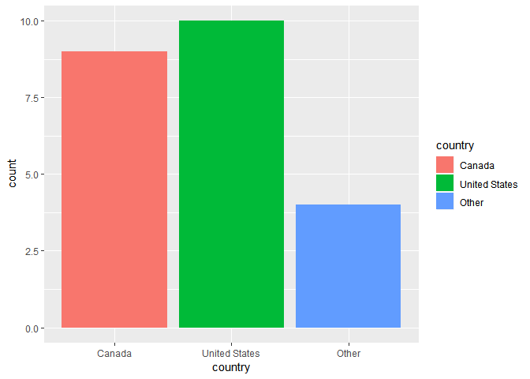

```r
gapminder %>%
  # show only a continent
  filter(continent == "Americas") %>%
  # filter countreis with gdpPercap larger than 15,000
  filter(gdpPercap >= 15000) %>%
  # reorder levels of country, and let forcats lump groups for us
  mutate(
    country = country %>% fct_infreq() %>% fct_rev() %>% fct_lump()
  ) %>%
  # country as x axis
  ggplot(aes(x = country, fill = country)) +
  # make it as a bar plot
  geom_bar()
```

# Refereces

- [R for Data Science - Factors](http://r4ds.had.co.nz/factors.html)